# Veri Madenciliği Final

## 5)Boosting

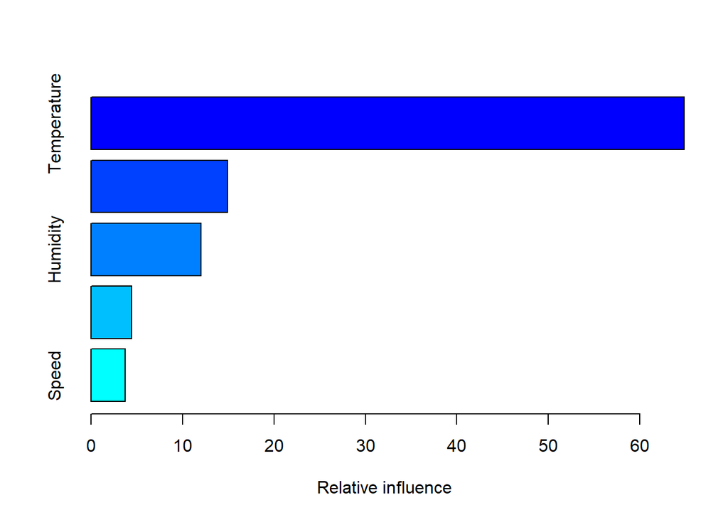

```
##                                           var   rel.inf
## Temperature                       Temperature 64.836820
## WindDirection.Degrees. WindDirection.Degrees. 14.910782
## Humidity                             Humidity 12.050354
## Pressure                             Pressure  4.440417
## Speed                                   Speed  3.761627
```

```r
set.seed(500)
boost.Solar=gbm(Radiation~.,data=Solar[train,],distribution="gaussian",n.trees=5000,interaction.depth=4)
summary(boost.Solar)
```

En önemli değişkenin sıcaklık değişkeni olduğu anlaşılmaktadır.Daha sonra ise rüzgar yönü değişkeni gelmektedir.İkisinin grafiklerini inceleyelim.

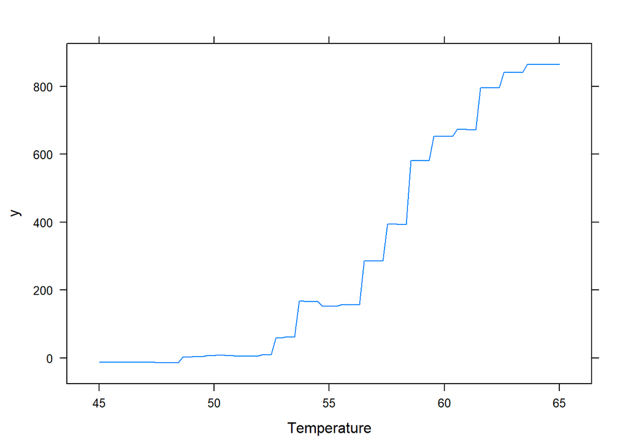

```r
plot(boost.Solar,i="Temperature")
```

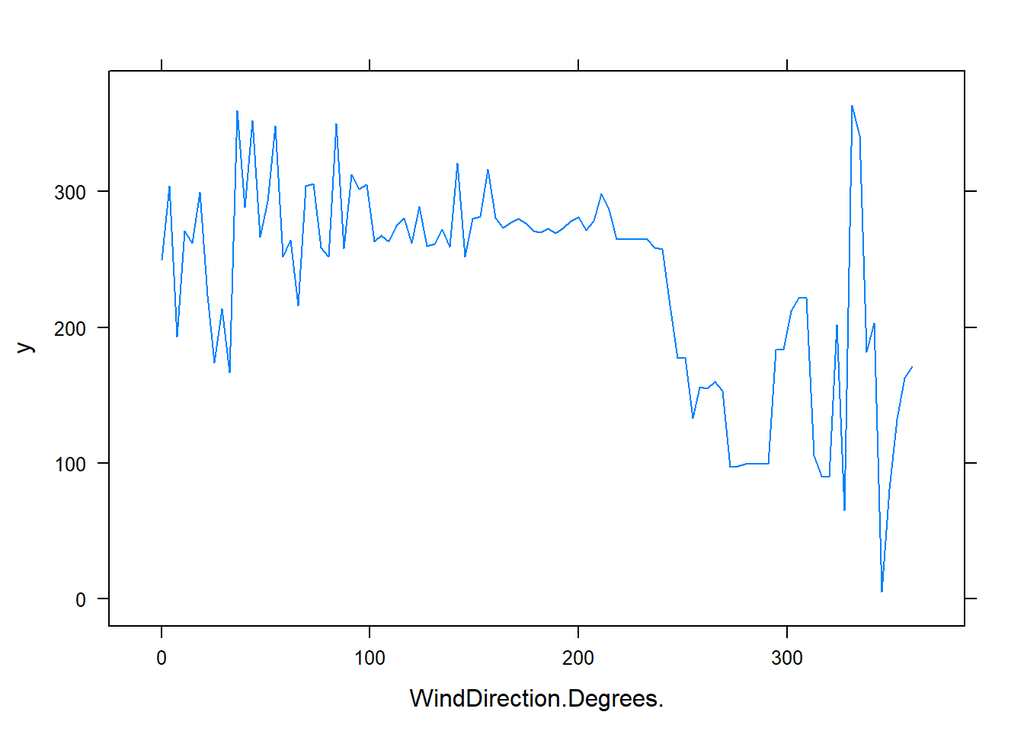

```r
plot(boost.Solar,i="WindDirection.Degrees.")
```

Şimdi modelin test verisi üzerindeki performansını inceleyelim.

```r
yhat.boost=predict(boost.Solar,newdata=Solar[-train,],n.trees=5000)
mean((yhat.boost-Solar.test)^2)
```

```
## [1] 18431.28
```

# 2. Soru sonuçları

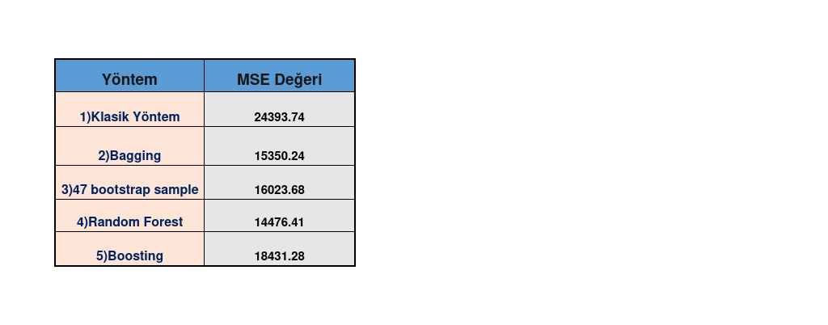

MSE Değerinin düşük olması tahmin performansının iyi olduğu anlamına gelmektedir.Bu durumda tahmin performansı en iyi olan yöntem Random Forest yöntemi olmuştur.Tahmin performansı en kötü olan yöntem ise Klasik yöntem olmuştur.Random Foresttan sonra en iyi tahmin performansı Bagging yöntemindedir.

# 3.SORU

Veri ülkelere ait bazı bilgileri içermektedir.

**Değişkenler**

**1)** **country:** *Ülkenin adı*

**2)** **child_mort:** *1000 canlı doğumda 5 yaşın altındaki çocukların ölümü*

**3)** **exports:** *Kişi başına mal ve hizmet ihracatı. Kişi başına düşen GSYİH’nin % si olarak verilir.*

**4)** **health:** *Kişi başına toplam sağlık harcaması. Kişi başına düşen GSYİH’nın % si olarak verilir.*

**5)** **imports:** *Kişi başına mal ve hizmet ithalatı. Kişi başına düşen GSYİH’nin % si olarak verilir.*

**6)** **income:** *Kişi başına net gelir*

**7)** **inflation:** *Toplam GSYİH’nin yıllık büyüme oranının ölçümü*

**8)** **life_expec:** *Mevcut ölüm oranları aynı kalacaksa, yeni doğan bir çocuğun yaşayacağı ortalama yıl sayısı*

**9)** **total_fer:** *Mevcut yaş-doğurganlık oranları aynı kalırsa her kadının doğacağı çocuk sayısı.*

**10)** **gdpp:** *Kişi başına düşen GSYİH. Toplam GSYİH’nin toplam nüfusa bölünmesiyle hesaplanır.*

Country

| country | child_mort | exports | health | imports | income | inflation | life_expec | total_fer | gdpp |
| --- | --- | --- | --- | --- | --- | --- | --- | --- | --- |
| Afghanistan | 90.2 | 10.0 | 7.58 | 44.9 | 1610 | 9.44 | 56.2 | 5.82 | 553 |
| Albania | 16.6 | 28.0 | 6.55 | 48.6 | 9930 | 4.49 | 76.3 | 1.65 | 4090 |
| Algeria | 27.3 | 38.4 | 4.17 | 31.4 | 12900 | 16.10 | 76.5 | 2.89 | 4460 |
| Angola | 119.0 | 62.3 | 2.85 | 42.9 | 5900 | 22.40 | 60.1 | 6.16 | 3530 |
| Antigua and Barbuda | 10.3 | 45.5 | 6.03 | 58.9 | 19100 | 1.44 | 76.8 | 2.13 | 12200 |
| Argentina | 14.5 | 18.9 | 8.10 | 16.0 | 18700 | 20.90 | 75.8 | 2.37 | 10300 |

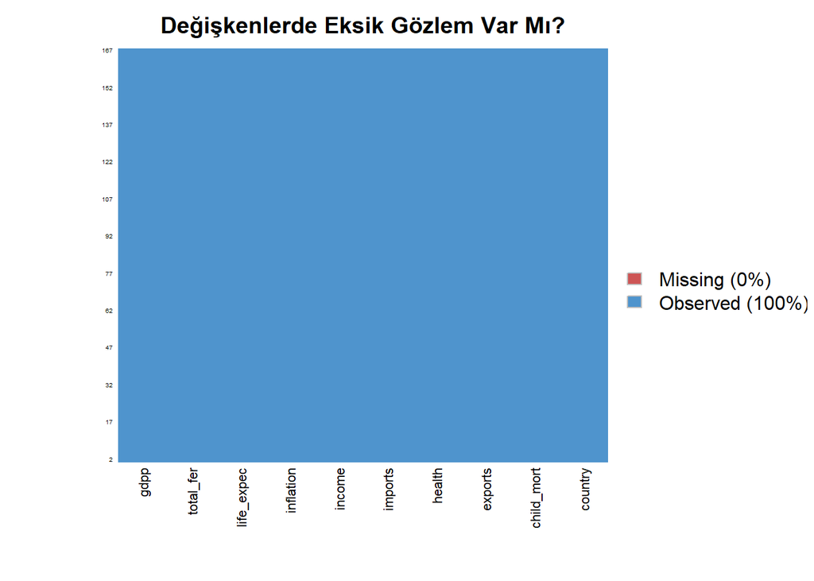

Veride eksik gözlem yoktur.

```r
dim(Country)
```

```
## [1] 167  10
```

## K-means-clustring

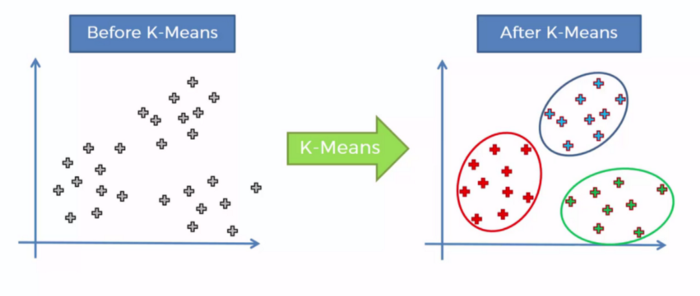

```r
Country=Country%>%select(-c(country))
summary(Country)
```

```
##    child_mort        exports            health          imports
##  Min.   :  2.60   Min.   :  0.109   Min.   : 1.810   Min.   :  0.0659
##  1st Qu.:  8.25   1st Qu.: 23.800   1st Qu.: 4.920   1st Qu.: 30.2000
##  Median : 19.30   Median : 35.000   Median : 6.320   Median : 43.3000
##  Mean   : 38.27   Mean   : 41.109   Mean   : 6.816   Mean   : 46.8902
##  3rd Qu.: 62.10   3rd Qu.: 51.350   3rd Qu.: 8.600   3rd Qu.: 58.7500
##  Max.   :208.00   Max.   :200.000   Max.   :17.900   Max.   :174.0000
##      income         inflation         life_expec      total_fer
##  Min.   :   609   Min.   : -4.210   Min.   :32.10   Min.   :1.150
##  1st Qu.:  3355   1st Qu.:  1.810   1st Qu.:65.30   1st Qu.:1.795
##  Median :  9960   Median :  5.390   Median :73.10   Median :2.410
##  Mean   : 17145   Mean   :  7.782   Mean   :70.56   Mean   :2.948
##  3rd Qu.: 22800   3rd Qu.: 10.750   3rd Qu.:76.80   3rd Qu.:3.880
##  Max.   :125000   Max.   :104.000   Max.   :82.80   Max.   :7.490
##       gdpp
##  Min.   :   231
##  1st Qu.:  1330
##  Median :  4660
##  Mean   : 12964
##  3rd Qu.: 14050
##  Max.   :105000
```

```r
library(dplyr)
rescale_df <- Country %>%
mutate(child_mort_scal = scale(child_mort),
    exports_scal = scale(exports),
    health_scal = scale(health),
    imports_scal = scale(imports),
    income_scal = scale(income),
    inflation_scal = scale(inflation),
    life_expec_scal = scale(life_expec),
    total_fer_scal = scale(total_fer),
    gdpp_scal = scale(gdpp)) %>%
  select(-c(child_mort, exports, health, imports, income, inflation,life_expec,total_fer,gdpp))
```

```r
head(rescale_df)
```

```
##   child_mort_scal exports_scal health_scal imports_scal income_scal
## 1       1.2876597  -1.13486665  0.27825140  -0.08220771 -0.80582187
## 2      -0.5373329  -0.47822017 -0.09672528   0.07062429 -0.37424335
## 3      -0.2720146  -0.09882442 -0.96317624  -0.63983800 -0.22018227
## 4       2.0017872   0.77305618 -1.44372888  -0.16481961 -0.58328920
## 5      -0.6935483   0.16018613 -0.28603389   0.49607554  0.10142673
## 6      -0.5894047  -0.81019144  0.46756001  -1.27594958  0.08067776
##   inflation_scal life_expec_scal total_fer_scal   gdpp_scal
## 1      0.1568645      -1.6142372     1.89717646 -0.67714308
## 2     -0.3114109       0.6459238    -0.85739418 -0.48416709
## 3      0.7869076       0.6684130    -0.03828924 -0.46398018
## 4      1.3828944      -1.1756985     2.12176975 -0.51472026
## 5     -0.5999442       0.7021467    -0.54032130 -0.04169175
## 6      1.2409928       0.5897009    -0.38178486 -0.14535428
```

Veri setimizde k-ortalama algoritmasını beş küme ile çalıştırıp ve ona pc_cluster diyelim.

```r
pc_cluster <-kmeans(rescale_df, 5)
pc_cluster
```

```
## K-means clustering with 5 clusters of sizes 34, 14, 55, 37, 27
##
## Cluster means:
##   child_mort_scal exports_scal health_scal imports_scal income_scal
## 1       1.3767069   -0.3936823  -0.6035113   -0.3802180  -0.6962048
## 2       1.1967997   -0.5284588   1.1392415    0.5297104  -0.6999132
## 3      -0.3515876   -0.3811234  -0.2515480   -0.4156850  -0.3004808
## 4      -0.5912141    0.9327810  -0.2192249    0.9478733   0.1796419
## 5      -0.8278145    0.2678708   0.9820911   -0.2480434   1.6055348
##   inflation_scal life_expec_scal total_fer_scal   gdpp_scal
## 1      0.5900400      -1.1442798      1.5569837 -0.60917994
## 2     -0.1801181      -1.5981735      0.7963862 -0.59489505
## 3      0.1391654       0.2368255     -0.3636493 -0.36979904
## 4     -0.3206460       0.4787746     -0.6524394 -0.05692409
## 5     -0.4937002       1.1311067     -0.7387365  1.90688101
##
## Clustering vector:
##   [1] 1 3 3 1 4 3 3 5 5 3 3 4 3 3 4 5 4 1 4 3 3 2 3 5 4 1 2 3 1 5 3 1 1 3 3 3 1
##  [38] 1 1 3 1 3 4 4 5 3 3 3 3 1 1 4 4 5 5 1 1 3 5 1 5 3 3 1 2 4 2 4 5 3 3 3 3 5
##  [75] 5 5 3 5 4 3 1 2 5 4 1 4 4 2 2 4 4 5 4 1 1 4 4 1 4 1 4 2 4 3 4 3 1 3 2 3 5
## [112] 5 1 1 5 4 1 4 3 3 3 3 5 5 3 3 2 3 3 1 3 4 2 4 4 4 2 2 4 5 3 3 1 3 5 5 3 1
## [149] 4 1 2 3 4 3 4 1 3 4 5 5 3 3 3 3 4 1 1
##
## Within cluster sum of squares by cluster:
## [1] 167.79607  66.20912 136.25650 163.93857 168.99209
##  (between_SS / total_SS =  52.9 %)
##
## Available components:
##
## [1] "cluster"      "centers"      "totss"        "withinss"     "tot.withinss"
## [6] "betweenss"    "size"         "iter"         "ifault"
```

**Pc_cluster listesi yedi ilginç öğe içerir:**

**pc_cluster $ cluster: Her gözlemin kümesini gösterir**

**pc_cluster $ centers: Küme merkezleri**

**pc_cluster $ totss: Kareler Toplamı (Gözlemlerin genel ortalamadan uzaklıklarının kareleri toplamı)ANOVA daki SST gibi**

**pc_cluster $ withinss: Grup içi kareler toplamları**

**pc_cluster $ tot.withinss: Grup içi kareler toplamlarının toplamı**

**pc_clusterbetweenss: pc_cluster $ totss-pc_cluster $ tot.withinss**

**pc_cluster $ size: Her bir küme içindeki gözlem sayısı**

Optimal küme sayısını hesaplamak için Grup içi kareler toplamlarının toplamını (yani tot.withinss) kullanılabilir. K’yi bulmak gerçekten önemli bir konudur.

```r
kmean_withinss <- function(k) {
    cluster <- kmeans(rescale_df, k)
    return (cluster$tot.withinss)
}
# maksimum küme ayarlamak
max_k <-20
set.seed(100)
# k aralığında algoritma
wss <- sapply(2:max_k, kmean_withinss)
```

```r
# grafik çizmek için veri çerçevesi
elbow <-data.frame(2:max_k, wss)
```

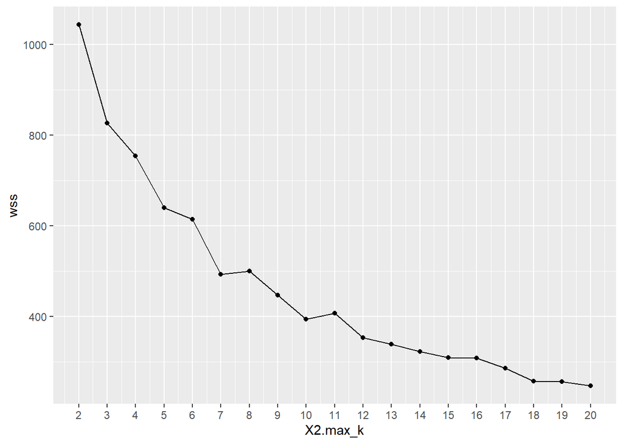

```r
# Plot the graph with gglop
ggplot(elbow, aes(x = X2.max_k, y = wss)) +
    geom_point() +
    geom_line() +
    scale_x_continuous(breaks = seq(1, 20, by = 1))
```

Grafikten optimal k’nin yedi olduğunu görebiliriz, burada k daki artışın etkisi azalmaya başlamıştır.

**Kümenin incelenmesi**

```r
pc_cluster_2 <-kmeans(rescale_df, 7)
pc_cluster_2$cluster
```

```
##   [1] 6 2 4 6 5 2 4 1 1 4 2 5 4 2 5 1 5 6 4 4 2 4 2 1 5 6 6 4 6 1 4 6 6 2 4 2 6
##  [38] 6 4 2 6 2 5 5 1 4 2 4 2 6 4 5 4 1 1 4 6 2 1 6 2 2 4 6 6 4 6 5 1 4 4 4 4 1
##  [75] 1 1 4 1 2 4 4 6 1 4 4 5 2 6 6 5 5 7 2 6 6 5 5 6 7 6 5 2 2 4 2 4 6 4 4 4 1
## [112] 1 6 3 1 5 4 5 4 4 4 2 2 1 2 4 6 4 5 6 2 5 6 7 5 5 4 4 5 1 4 4 6 4 1 1 4 6
## [149] 5 6 6 4 5 2 4 6 2 5 1 1 2 4 4 4 5 4 6
```

```r
pc_cluster_2$centers
```

```
##   child_mort_scal exports_scal  health_scal imports_scal income_scal
## 1    -0.823624431    0.1437700  0.974051570  -0.39854243   1.5983783
## 2    -0.608621627   -0.3599196  0.645426898  -0.11982563  -0.1509511
## 3     2.274544274   -0.5767171 -0.635526719  -1.21812126  -0.6221935
## 4    -0.008085012   -0.2347656 -0.643026253  -0.25778616  -0.4745439
## 5    -0.683725183    0.8631346 -0.318098740   0.63778672   0.3477609
## 6     1.578695013   -0.5217673 -0.010496245  -0.09023287  -0.7463865
## 7    -0.846457501    4.9208731 -0.008138555   4.53442030   2.4322274
##   inflation_scal life_expec_scal total_fer_scal   gdpp_scal
## 1     -0.4828478       1.1327205    -0.71151864  1.88265772
## 2     -0.2651814       0.5467305    -0.68753371 -0.19584105
## 3      9.1023425      -1.1307201     1.91038783 -0.58019133
## 4      0.2655062      -0.2282300     0.01098917 -0.50344723
## 5     -0.2840275       0.5654818    -0.68793295  0.03362098
## 6      0.1579591      -1.3806711     1.56745842 -0.63206469
## 7     -0.5026943       1.2231457    -1.03574767  2.43347860
```

```r
pc_cluster_2$size
```

```
## [1] 24 28  1 50 26 35  3
```

```r
kmeans <- eclust(rescale_df, "kmeans",nstart=25)
```

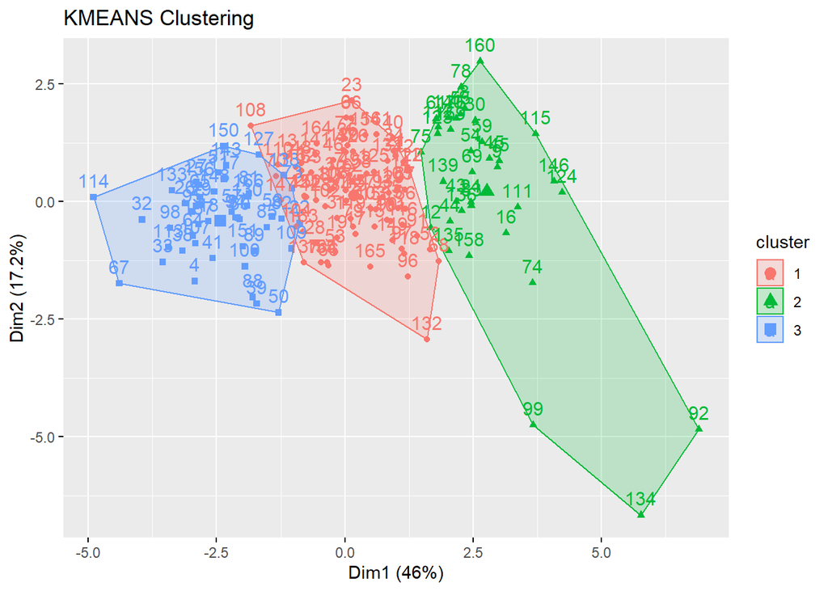

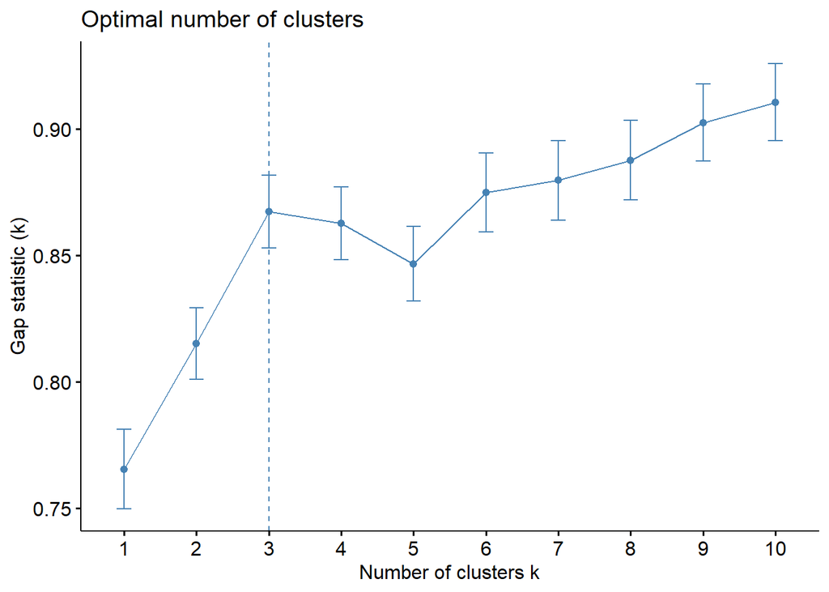

```r
# Gap statistic plot
fviz_gap_stat(kmeans$gap_stat)
```

```
##   cluster size ave.sil.width
## 1       1   84          0.36
## 2       2   36          0.15
## 3       3   47          0.24
```

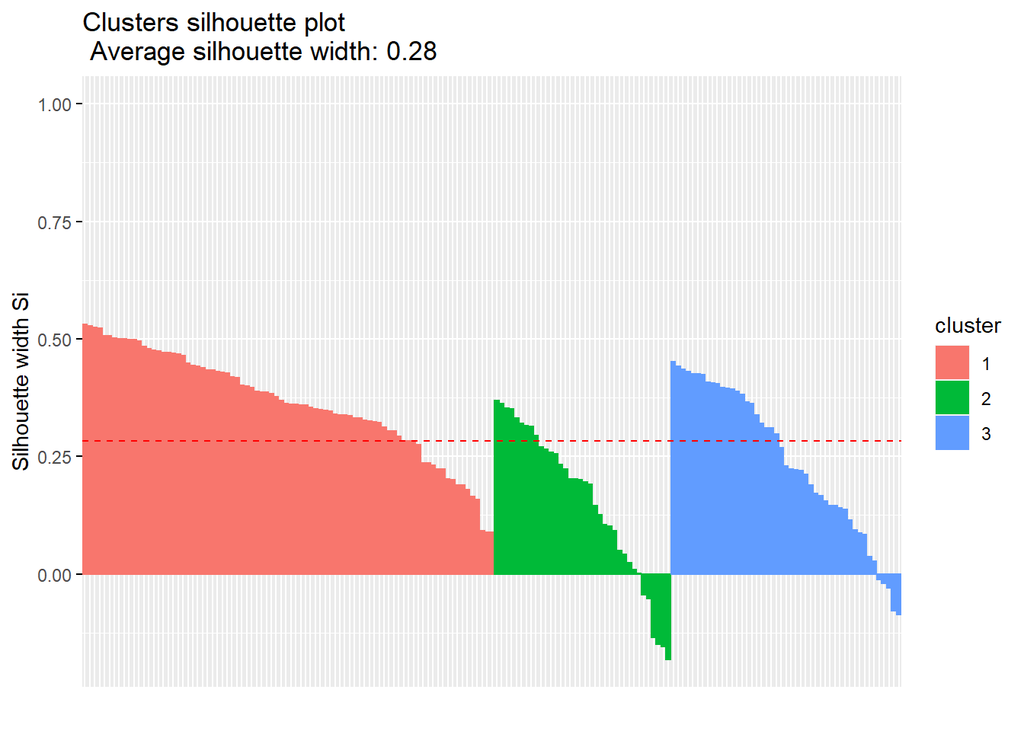

```r
# Silhouette plot
fviz_silhouette(kmeans)
```

## Hierarchical clustring:

```r
head(Country)
```

```
##   child_mort exports health imports income inflation life_expec total_fer  gdpp
## 1       90.2    10.0   7.58    44.9   1610      9.44       56.2      5.82   553
## 2       16.6    28.0   6.55    48.6   9930      4.49       76.3      1.65  4090
## 3       27.3    38.4   4.17    31.4  12900     16.10       76.5      2.89  4460
## 4      119.0    62.3   2.85    42.9   5900     22.40       60.1      6.16  3530
## 5       10.3    45.5   6.03    58.9  19100      1.44       76.8      2.13 12200
## 6       14.5    18.9   8.10    16.0  18700     20.90       75.8      2.37 10300
```

```r
hc<-hclust(dist(Country,method="euclidean"),method="ward.D2")
hc
```

```
##
## Call:
## hclust(d = dist(Country, method = "euclidean"), method = "ward.D2")
##
## Cluster method   : ward.D2
## Distance         : euclidean
## Number of objects: 167
```

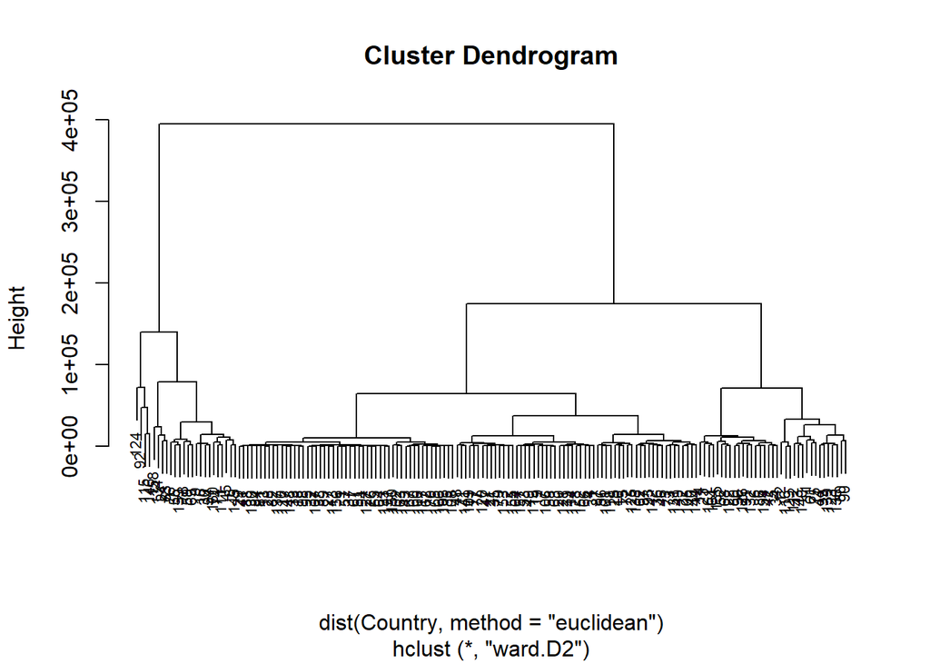

```r
plot(hc,cex=0.7)
```

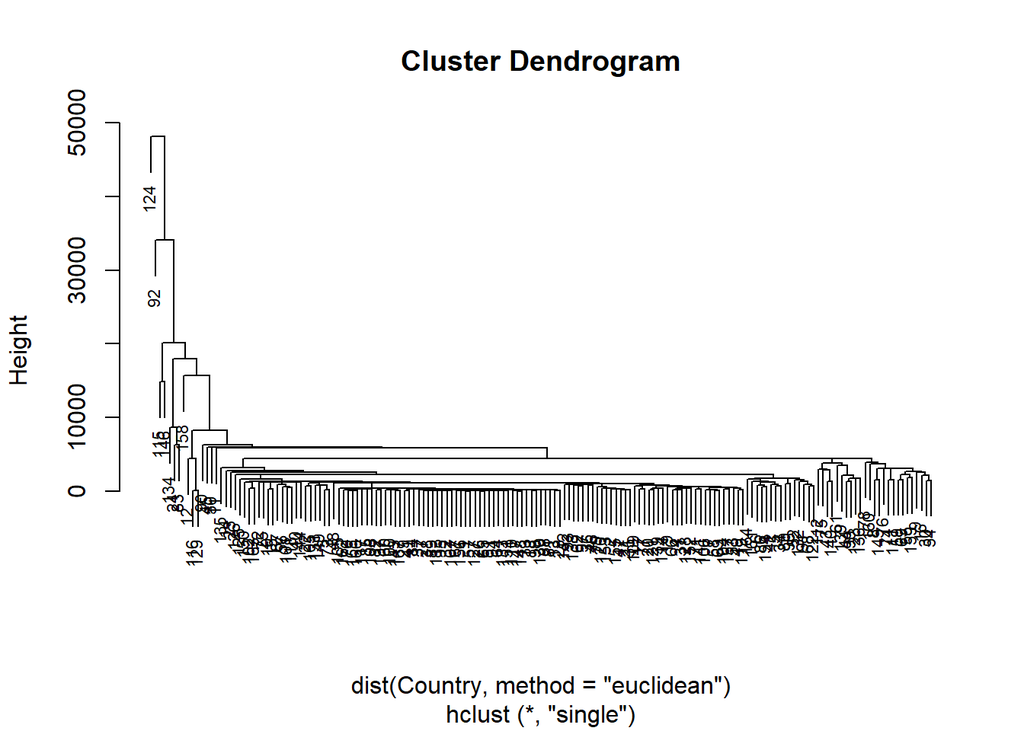

```r
hc2<-hclust(dist(Country,method="euclidean"),method="single")
plot(hc2,cex=0.7)
```

Alternatif olarak, agnes fonksiyonunu da kullanabiliriz. Bu fonksiyon çok benzer şekilde davranır; ancak, agnes fonksiyonu ile, bulunan kümeleme yapısının gücünü ölçen aglomeratif katsayıyı da elde edebilir (1’e yakın değerler güçlü kümeleme yapısını gösterir).

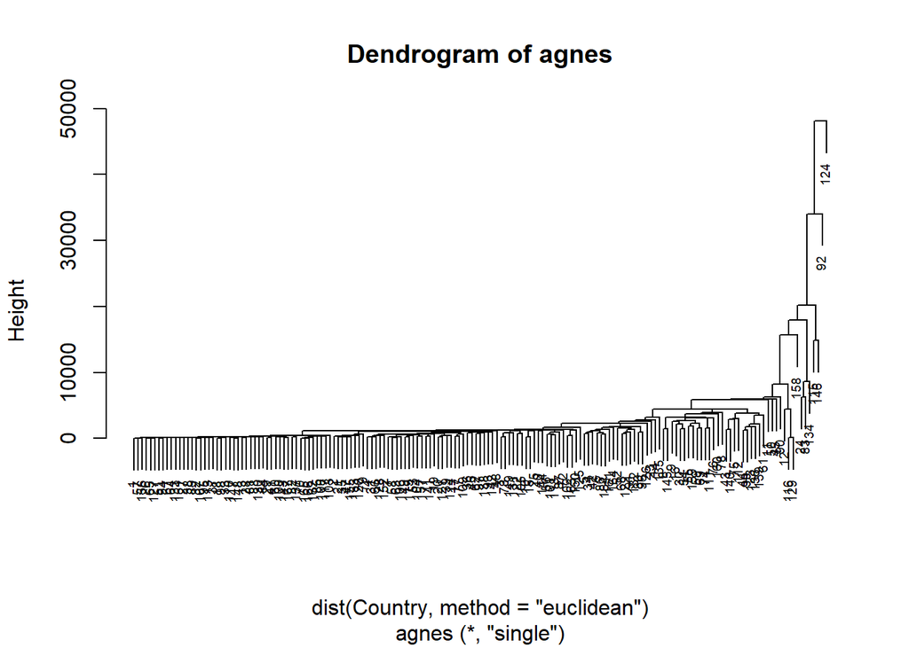

```r
hc3<-agnes(dist(Country,method="euclidean"), method = "single")
pltree(hc3, cex = 0.6, main = "Dendrogram of agnes")
```

```r
hc3$ac
```

```
## [1] 0.9631544
```

Sonuç 1 e yakındır.Bu güçlü kümeleme göstergesidir.

Linkage methodları karşılaştırmak için aglomeratif katsayıyı aşağıdaki gibi kullanabiliriz.

```r
m <- c( "average", "single", "complete", "ward")
names(m) <- c( "average", "single", "complete", "ward")
ac <- function(x) {
agnes(dist(Country,method="euclidean"), method = x)$ac
}
map_dbl(m, ac)
```

```
##   average    single  complete      ward
## 0.9795481 0.9631544 0.9845210 0.9943727
```

Bu, daha güçlü kümeleme yapılarını tanımlayabilen belirli hiyerarşik kümeleme yöntemlerini bulmamızı sağlar. Burada Ward yönteminin değerlendirilen dört yöntemin en güçlü kümeleme yapısını belirlediğini görüyoruz.

**Cutting Tree**

Dendrograma kadar olan kesimin yüksekliği, elde edilen küme sayısını kontrol eder. K-ortalamalı kümelemede k ile aynı rolü oynar. Alt grupları (yani kümeleri) tanımlamak için, dendrogramı cutree ile kesebiliriz:

```r
sub_grp <- cutree(hc, k = 4)
table(sub_grp)
```

```
## sub_grp
##   1   2   3   4
## 108  35  20   4
```

Sonucu bir dağılım grafiğinde görselleştirmek için factoextra paketindeki fviz_cluster fonksiyonunu da kullanabiliriz.

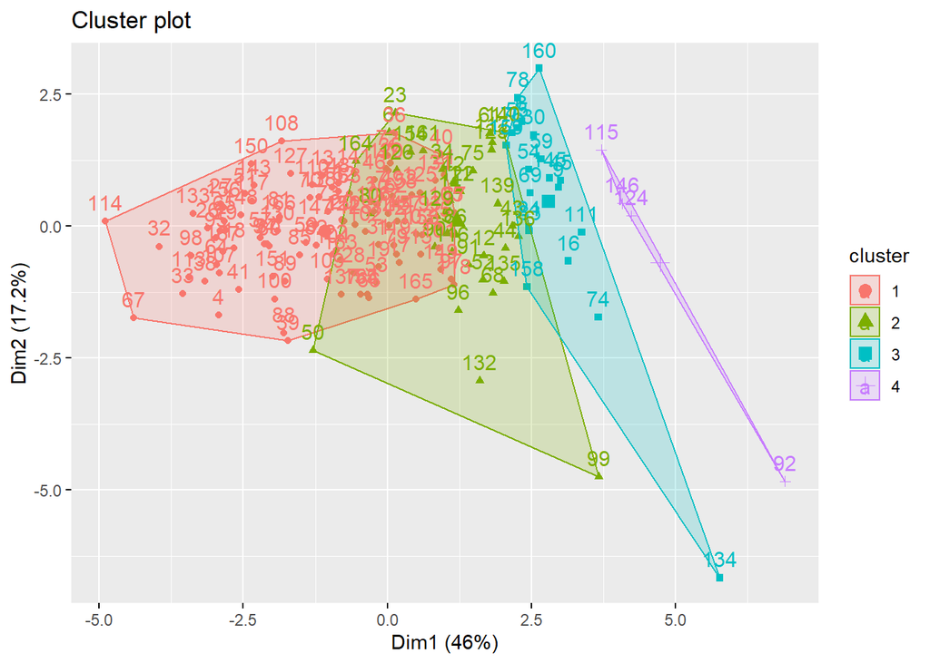

```r
fviz_cluster(list(data =Country, cluster = sub_grp))
```

Bu grafikten 4 küme yerine 3 küme kullanabileceğimiz sonucuna ulaşabiliriz.

K-ortalamalı kümeleme ile optimum küme sayısını belirleme şeklimize benzer şekilde, hiyerarşik kümeleme için benzer yaklaşımları uygulayabiliriz:

**Elbow Method**

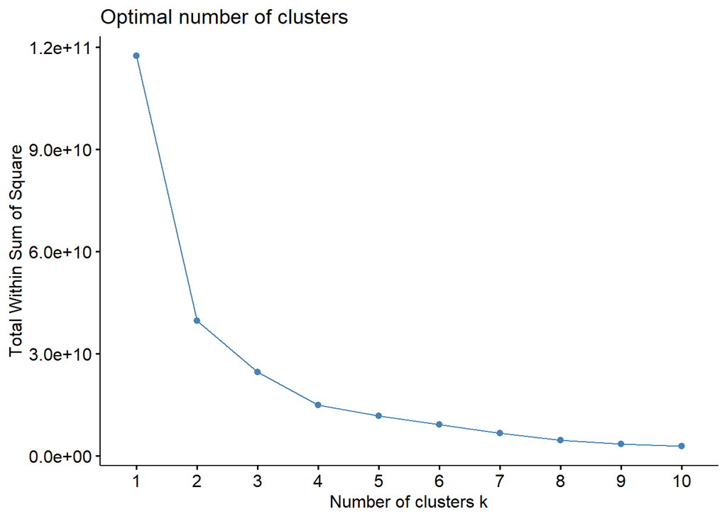

```r
fviz_nbclust(Country, FUN = hcut, method = "wss")
```

**Average Silhouette Method**

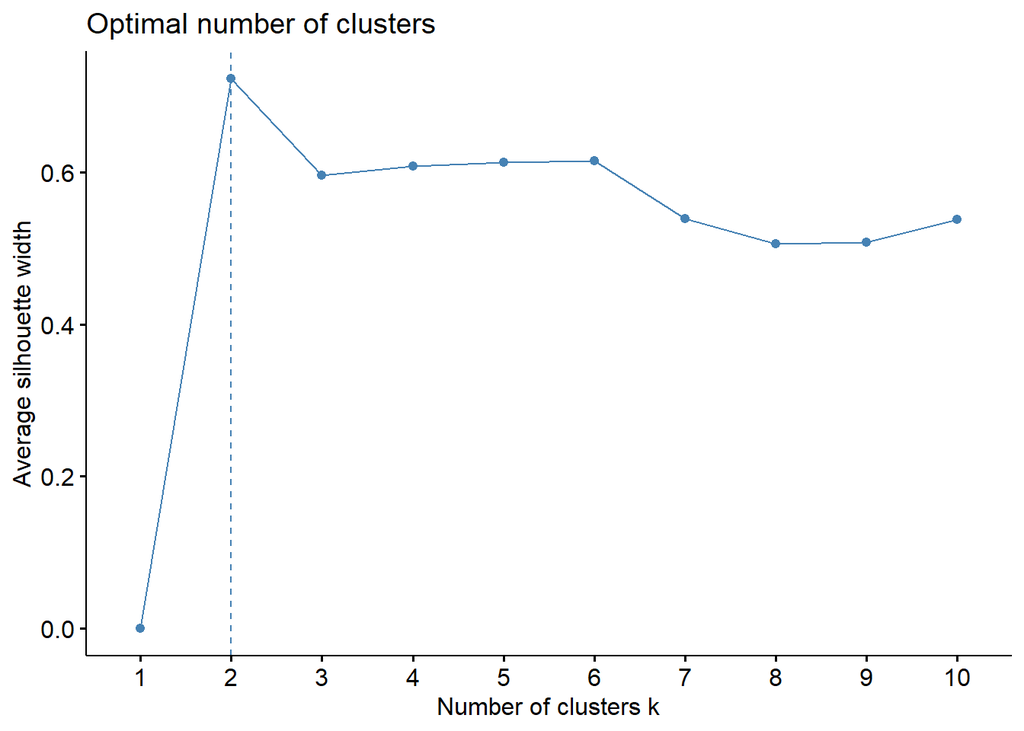

```r
fviz_nbclust(Country, FUN = hcut, method = "silhouette")
```

**Gap Statistic Method**

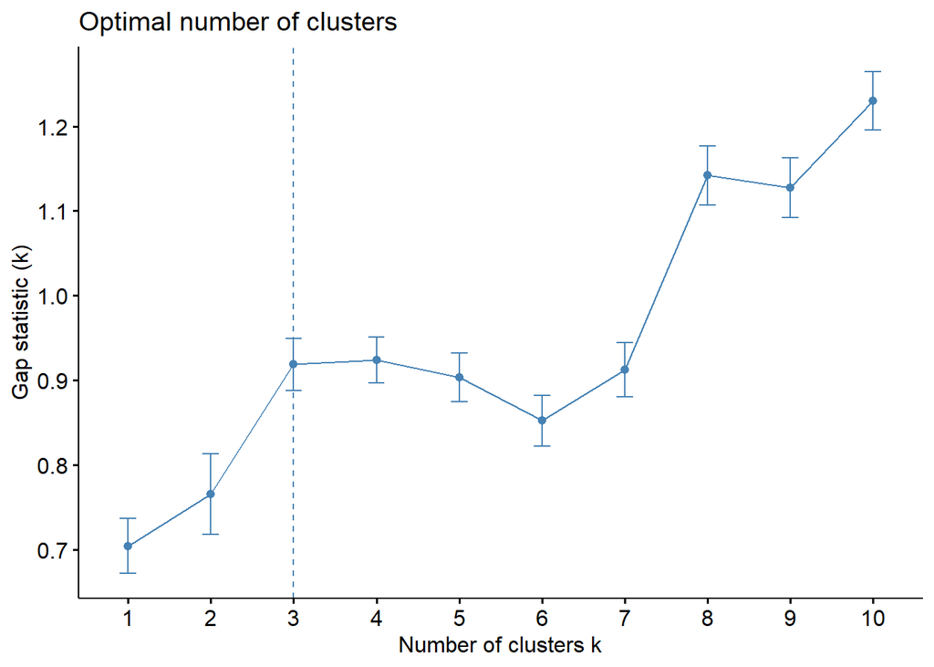

```r
gap_stat <- clusGap(Country, FUN = hcut, nstart = 25, K.max = 10, B = 50)
fviz_gap_stat(gap_stat)
```

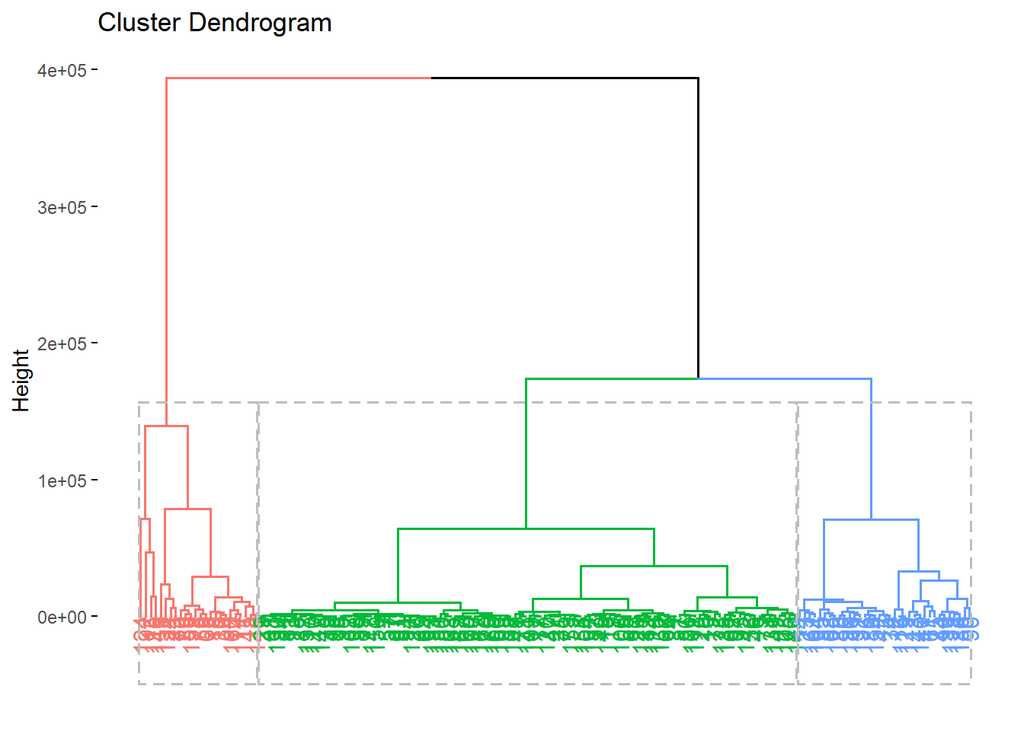

```r
hclust <- eclust(Country, "hclust",nstart=25)
fviz_dend(hclust,rect=TRUE)
```

```
##   cluster size ave.sil.width
## 1       1  108          0.72
## 2       2   35          0.41
## 3       3   24          0.33
```

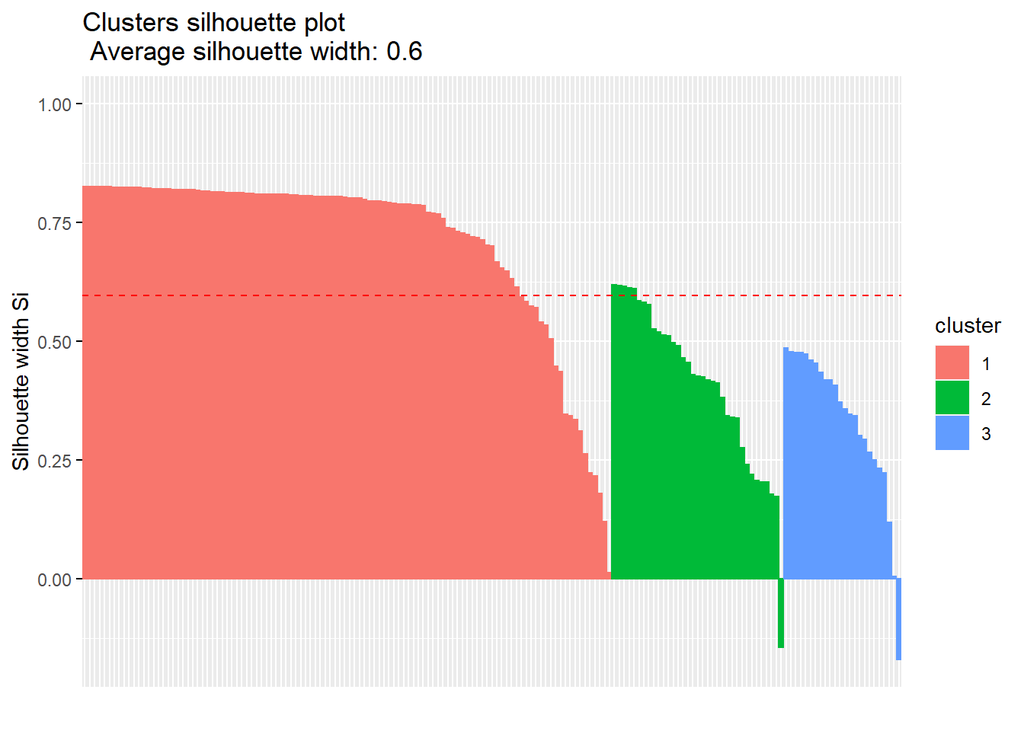

```r
fviz_silhouette(hclust) # silhouette plot
```

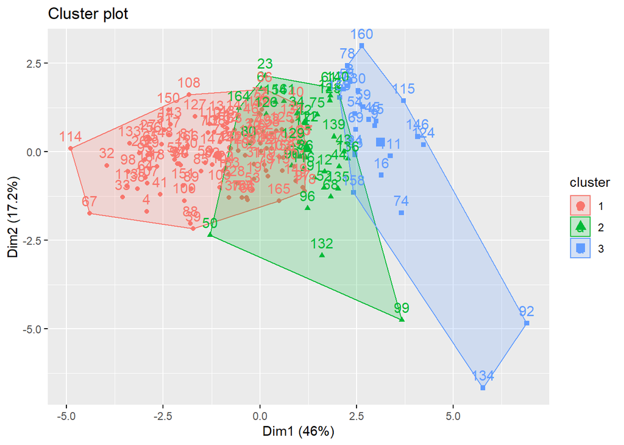

```r
fviz_cluster(hclust) # scatter plot
```